# Cluster Analysis in R

Andrew Mitchell

13/06/2020

## Clustering Analysis Libraries

`factoextra`:

- https://www.rdocumentation.org/packages/factoextra/versions/1.0.3

`NbClust`:

- https://www.rdocumentation.org/packages/NbClust/versions/3.0
- https://www.jstatsoft.org/article/view/v061i06/v61i06.pdf

There are many libraries and functions in R for performing clustering analysis, so why look at these 2? Well, they solve two important challenges with clustering: visualisation and determining the optimal number of clusters.

In general, cluster analysis is an unsupervised machine learning task, meaning we don’t predefine a target output for the learning. For clustering, this mainly means that we don’t know what the categories will be before we start the analysis. We also don’t know how many clusters are present.

Many indices have been created to help with determining the optimal number of clusters, however these each have their own advantages and disadvantages and often give conflicting results. We’ll demonstrate this by looking at the results from three popular graphical methods: elbow plot, silhouette, and gap statistic.

## Dataset

We’ll be looking at data from the [Soundscape Indices (SSID) Database](https://www.mdpi.com/2076-3417/10/7/2397). This dataset contains data in-situ perceptual assessments of urban soundscapes, paired with acoustic and environmental data. For this set, we’ll be looking at the perceptual data only.

To collect the data, random members of the public were approached while in urban public spaces and asked to take a survey about how they perceive the sound environment. A section of the questions ask specifically about the perceived dominance of sound sources in the space. Sound sources are categorized as Traffic noise, Other noise, Human sounds, Natural sounds, and are rated from 1 [not at all] to 5 [dominates completely].

The data was collected across 27 locations in the UK, Italy, Spain, the Netherlands, and China. The goal here is to investigate whether these locations can be categorized based on their composition of sound sources.

```
## # A tibble: 6 x 6
##   GroupID Traffic Other Natural Human LocationID
##   <fct>     <dbl> <dbl>   <dbl> <dbl> <fct>
## 1 2cv11         1     1    4     3.5  CarloV
## 2 2cv12         1     1    3     4    CarloV
## 3 2cv13         1     1    3.67  3.67 CarloV
## 4 2cv14         1     1    3     5    CarloV
## 5 2cv15         2     1    3     2.5  CarloV
## 6 2cv21         1     1    2     3    CarloV
```

Our locations are:

```r
print(levels(ssid.data$LocationID))
```

```
##  [1] "CamdenTown"                "CampoPrincipe"
##  [3] "CarloV"                    "DadongSquare"
##  [5] "EustonTap"                 "Groningen-Noorderplantsoe"
##  [7] "MarchmontGarden"           "MiradorSanNicolas"
##  [9] "MonumentoGaribaldi"        "OlympicSquare"
## [11] "PancrasLock"               "PingshanPark"
## [13] "PingshanStreet"            "PlazaBibRambla"
## [15] "RegentsParkFields"         "RegentsParkJapan"
## [17] "RussellSq"                 "SanMarco"
## [19] "SidalinParkA"              "SidalinParkB"
## [21] "SofiaChurch"               "StPaulsCross"
## [23] "StPaulsRow"                "TateModern"
## [25] "TorringtonSq"              "ZhongshanPark"
## [27] "ZhongshanSquare"
```

## Calculate the mean value for each Location

**Note:** If the data use different scales, they should always be standardised before clustering. In this case, all of the data are on the same scale, so we don’t need to worry.

```r
means <- aggregate(ssid.data[c(vars)], by=list(ssid.data$LocationID), FUN=mean, na.rm=TRUE)
means <- data.frame(means[, -1], row.names = means[, 1])

means
```

```
##                            Traffic    Other  Natural    Human
## CamdenTown                3.787745 2.652941 1.316667 3.219608
## CampoPrincipe             1.250560 1.514240 3.825568 3.231903
## CarloV                    1.169040 1.169895 3.484318 3.403640
## DadongSquare              1.793103 1.919540 2.747126 3.068966
## EustonTap                 3.717857 2.858929 1.642262 2.515476
## Groningen-Noorderplantsoe 2.761111 1.783333 3.120833 2.822222
## MarchmontGarden           2.663542 2.412500 2.564583 2.695833
## MiradorSanNicolas         1.931373 1.470588 2.490196 3.686275
## MonumentoGaribaldi        1.903509 1.885965 2.982456 3.254386
## OlympicSquare             2.476331 2.511834 2.479290 2.994083
## PancrasLock               2.457500 3.144167 2.391667 2.453333
## PingshanPark              2.619658 2.807692 2.854701 3.465812
## PingshanStreet            2.803401 3.432993 2.453401 3.315646
## PlazaBibRambla            1.392857 1.250000 2.940476 3.488095
## RegentsParkFields         2.422886 1.911692 3.148010 2.866915
## RegentsParkJapan          1.867179 1.528718 3.974103 2.450000
## RussellSq                 2.668120 2.027132 3.334302 2.987403
## SanMarco                  1.431852 1.895926 2.230370 4.041852
## SidalinParkA              2.842667 2.832667 2.277000 3.309333
## SidalinParkB              2.909856 2.793797 2.065665 3.274239
## SofiaChurch               2.809589 2.926514 1.820824 2.975374
## StPaulsCross              2.503704 2.000000 2.266667 3.311111
## StPaulsRow                2.527132 2.294574 1.744186 3.368217
## TateModern                2.541667 2.150833 2.598333 3.660833
## TorringtonSq              3.230676 2.848068 1.957005 3.269565
## ZhongshanPark             2.353856 2.031095 2.381841 3.134328
## ZhongshanSquare           2.956184 2.433746 2.168375 2.708363
```

## Clustering Analysis

### Some standard, single indices

Elbow plot (within-sum-of-squares), Silhouette, Gap statistic

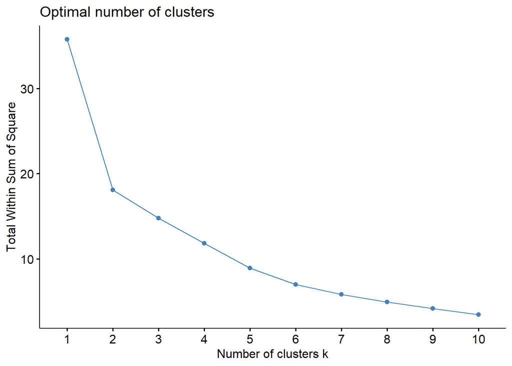

```r
set.seed(123)
fviz_nbclust(means, hcut, method="wss", ggtheme = theme_bw())
```

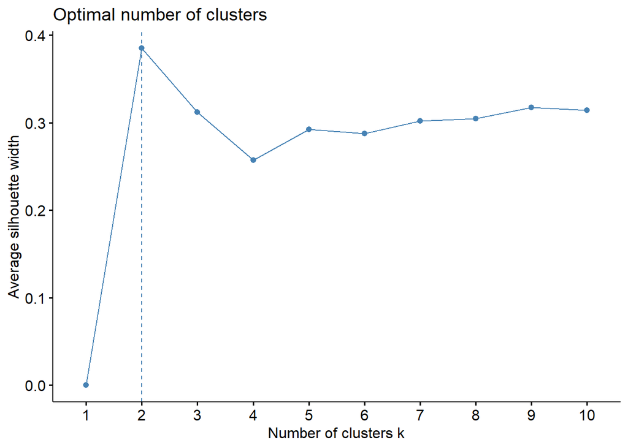

```r
fviz_nbclust(means, hcut, method="silhouette", ggtheme = theme_bw())
```

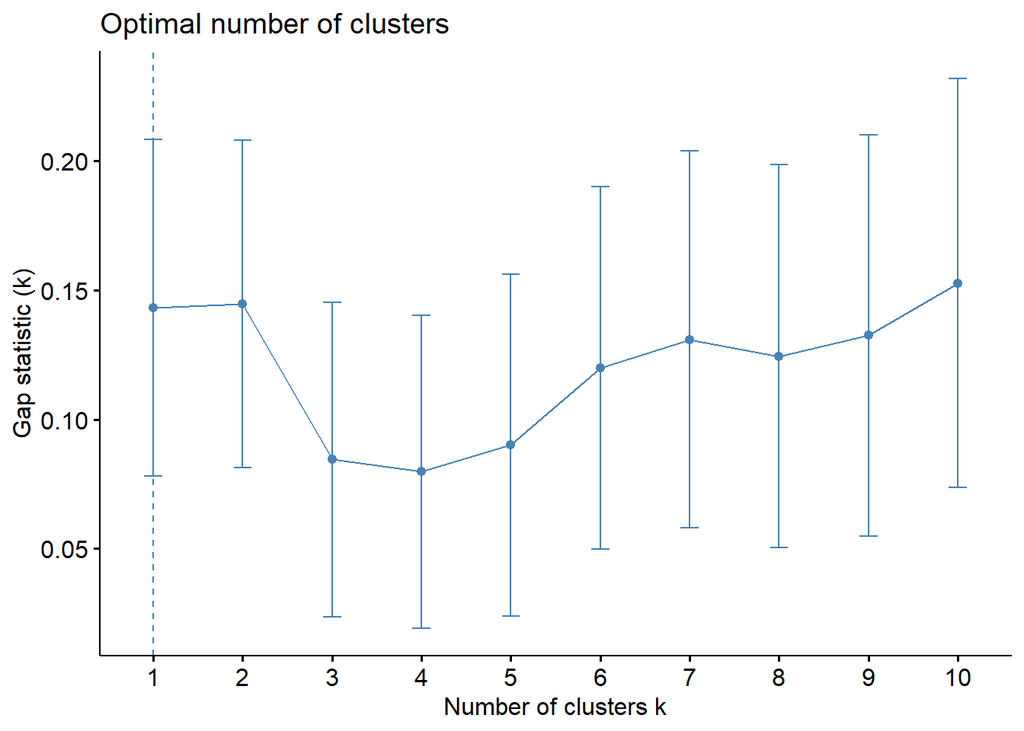

```r
fviz_nbclust(means, hcut, method="gap_stat", ggtheme=theme_bw())
```

As we can see, it can be less than obvious how to interpret some of these - where exactly is the ‘elbow’ in the elbow plot? Silhouette pretty clearly says k = 2, but the Gap stat gives k = 1, which isn’t very useful. How do we know which is right?

### 30 indices using NbClust

NbClust

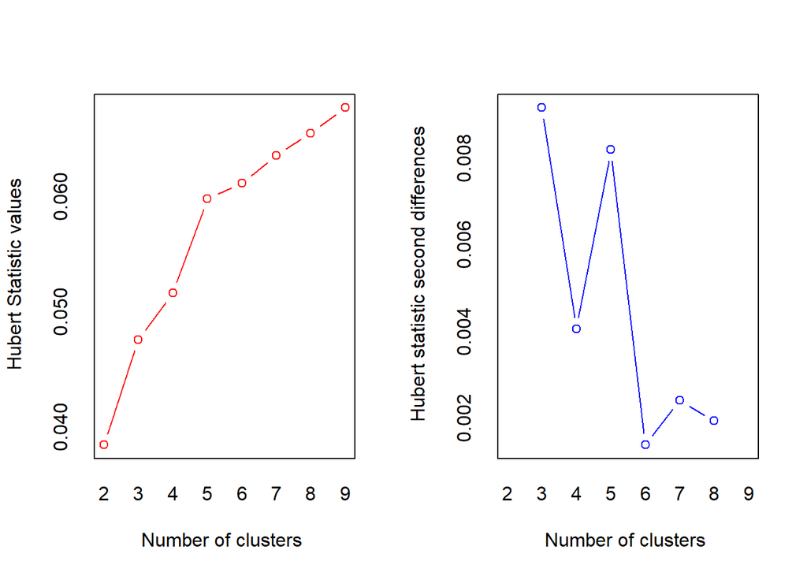

```
## *** : The Hubert index is a graphical method of determining the number of clusters.
##                 In the plot of Hubert index, we seek a significant knee that corresponds to a
##                 significant increase of the value of the measure i.e the significant peak in Hubert
##                 index second differences plot.
##
```

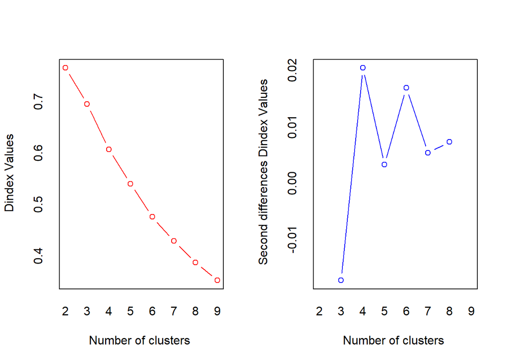

```
## *** : The D index is a graphical method of determining the number of clusters.
##                 In the plot of D index, we seek a significant knee (the significant peak in Dindex
##                 second differences plot) that corresponds to a significant increase of the value of
##                 the measure.
##
## * Among all indices:
## * 10 proposed 2 as the best number of clusters
## * 3 proposed 3 as the best number of clusters
## * 3 proposed 4 as the best number of clusters
## * 3 proposed 5 as the best number of clusters
## * 2 proposed 6 as the best number of clusters
## * 6 proposed 9 as the best number of clusters
##
##                    ***** Conclusion *****
##
## * According to the majority rule, the best number of clusters is  2
##
##
```

```r
indices = c("kl", "ch", "ccc", "cindex", "db", "silhouette", "duda", "pseudot2", "ratkowsky", "ptbiserial", "gap", "mcclain", "gamma", "gplus", "tau","sdindex", "sdbw")
res <- NbClust(data = means, distance='euclidean', min.nc = 2, max.nc=9, method="ward.D2", index = "alllong")
```

```r
print(res)
```

```
## $All.index
##         KL      CH Hartigan     CCC    Scott  Marriot  TrCovW  TraceW Friedman
## 2 135.7342 24.4784   5.5288 12.7400 198.5399 685.0329 34.7443 18.0685 267.7925
## 3   0.0380 17.0019   6.0302 10.2491 215.3189 827.9506 21.1728 14.7963 296.8703
## 4   0.5335 15.5179   7.4951  9.0900 242.9809 528.3707 14.5425 11.8251 391.5895
## 5   1.3056 16.5525   6.1008  8.8169 265.2216 362.2582  7.0864  8.9187 441.9125
## 6   1.6465 17.3099   4.2261  8.6241 285.9979 241.6536  4.1110  6.9824 493.6809
## 7   1.2054 17.1736   3.5740  8.2721 309.5738 137.3631  3.1125  5.8127 666.5872
## 8   1.0027 16.9682   3.4490  7.9325 324.9630 101.4657  2.0988  4.9314 754.1874
## 9   0.8648 17.0275   3.8532  7.6796 345.7552  59.4541  1.5336  4.1738 943.4628
##      Rubin Cindex     DB Silhouette   Duda Pseudot2   Beale Ratkowsky   Ball
## 2  42.9858 0.3987 1.0040     0.3849 0.6527   7.4505  1.1991    0.4196 9.0342
## 3  52.4921 0.3622 0.9344     0.3121 0.6564   4.7108  1.1373    0.3820 4.9321
## 4  65.6813 0.3287 0.8531     0.2570 0.4758   6.6114  2.2802    0.3684 2.9563
## 5  87.0850 0.4863 0.8328     0.2921 0.6675   5.9764  1.1099    0.3581 1.7837
## 6 111.2344 0.5119 0.9331     0.2874 0.6426   4.4489  1.1934    0.3438 1.1637
## 7 133.6196 0.4428 0.9677     0.3021 3.5864  -0.7212 -0.8705    0.3341 0.8304
## 8 157.4977 0.4859 0.8629     0.3414 0.5325   2.6334  1.5894    0.3215 0.6164
## 9 186.0873 0.4512 0.8300     0.3544 0.4528   4.8335  2.3338    0.3098 0.4638
##   Ptbiserial     Gap   Frey McClain  Gamma   Gplus     Tau   Dunn Hubert
## 2     0.5710 -0.3859 0.6378  0.5844 0.6696 14.4957 58.7578 0.2806 0.0384
## 3     0.5841 -0.7846 0.6418  0.7684 0.7273 11.6496 62.1368 0.2806 0.0476
## 4     0.5828 -1.3747 0.3510  0.9776 0.7735  9.0484 61.8006 0.2756 0.0516
## 5     0.5922 -1.5251 1.1087  1.1185 0.8261  6.5014 61.7664 0.3796 0.0598
## 6     0.5013 -1.7839 0.7670  1.9644 0.8273  4.7350 45.3561 0.3949 0.0612
## 7     0.4284 -1.9898 0.1353  3.0842 0.8413  3.0541 32.3761 0.3949 0.0636
## 8     0.4286 -2.1676 0.2980  3.1598 0.8627  2.5385 31.8974 0.4421 0.0655
## 9     0.4136 -2.2243 0.3006  3.5554 0.8882  1.8063 28.6952 0.4500 0.0677
##   SDindex Dindex   SDbw
## 2  3.0776 0.7647 1.0140
## 3  2.9927 0.6943 0.3681
## 4  2.9884 0.6066 0.2795
## 5  2.8395 0.5394 0.2136
## 6  3.8181 0.4754 0.1901
## 7  4.4329 0.4282 0.1782
## 8  4.0119 0.3865 0.1270
## 9  4.0270 0.3520 0.1108
##
## $All.CriticalValues
##   CritValue_Duda CritValue_PseudoT2 Fvalue_Beale CritValue_Gap
```

[output cut: 27 more lines]

```
##                         2                         1                         2
##           MarchmontGarden         MiradorSanNicolas        MonumentoGaribaldi
##                         1                         2                         2
##             OlympicSquare               PancrasLock              PingshanPark
##                         1                         1                         1
##            PingshanStreet            PlazaBibRambla         RegentsParkFields
##                         1                         2                         2
##          RegentsParkJapan                 RussellSq                  SanMarco
##                         2                         2                         2
##              SidalinParkA              SidalinParkB               SofiaChurch
##                         1                         1                         1
##              StPaulsCross                StPaulsRow                TateModern
##                         1                         1                         1
##              TorringtonSq             ZhongshanPark           ZhongshanSquare
##                         1                         1                         1
```

```
## Among all indices:
## ===================
## * 2 proposed  0 as the best number of clusters
## * 1 proposed  1 as the best number of clusters
## * 10 proposed  2 as the best number of clusters
## * 3 proposed  3 as the best number of clusters
## * 3 proposed  4 as the best number of clusters
## * 3 proposed  5 as the best number of clusters
## * 2 proposed  6 as the best number of clusters
## * 6 proposed  9 as the best number of clusters
##
## Conclusion
## =========================
## * According to the majority rule, the best number of clusters is  2 .
```

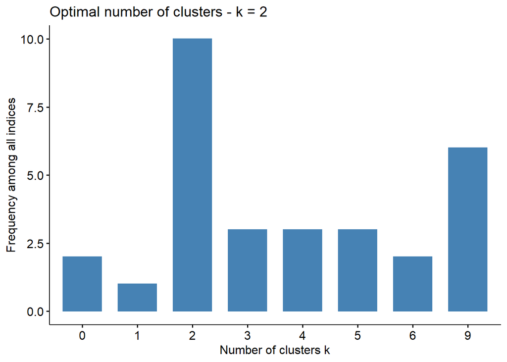

```r
fviz_nbclust(res)
```

```r
k = 2
k.fit <- kmeans(means, k)
print(k.fit)
```

```
## K-means clustering with 2 clusters of sizes 16, 11
##
## Cluster means:
##    Traffic    Other  Natural    Human
## 1 2.825085 2.633272 2.186404 3.104447
## 2 1.871963 1.668821 3.116160 3.209242
##
## Clustering vector:
##                CamdenTown             CampoPrincipe                    CarloV
##                         1                         2                         2
##              DadongSquare                 EustonTap Groningen-Noorderplantsoe
##                         2                         1                         2
##           MarchmontGarden         MiradorSanNicolas        MonumentoGaribaldi
##                         1                         2                         2
##             OlympicSquare               PancrasLock              PingshanPark
##                         1                         1                         1
##            PingshanStreet            PlazaBibRambla         RegentsParkFields
##                         1                         2                         2
##          RegentsParkJapan                 RussellSq                  SanMarco
##                         2                         2                         2
##              SidalinParkA              SidalinParkB               SofiaChurch
##                         1                         1                         1
##              StPaulsCross                StPaulsRow                TateModern
##                         1                         1                         1
##              TorringtonSq             ZhongshanPark           ZhongshanSquare
##                         1                         1                         1
##
## Within cluster sum of squares by cluster:
## [1] 9.420937 8.647528
##  (between_SS / total_SS =  49.5 %)
##
## Available components:
##
## [1] "cluster"      "centers"      "totss"        "withinss"     "tot.withinss"
## [6] "betweenss"    "size"         "iter"         "ifault"
```

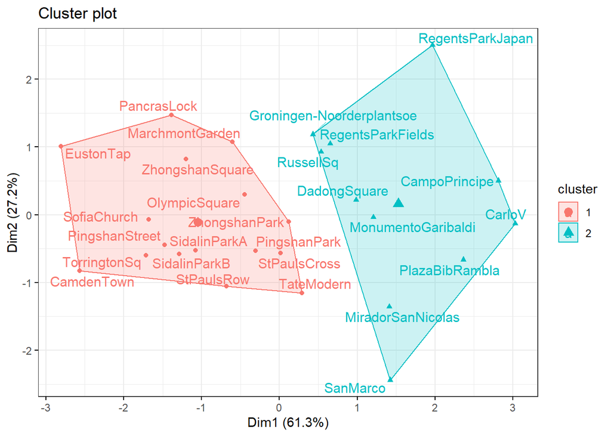

```r
fviz_cluster(k.fit, means, repel=TRUE, ggtheme = theme_bw())
```

```r
res.pca <- prcomp(means, scale=TRUE)
facto_summarize(res.pca, "var")
```

```
##            name      Dim.1       Dim.2     coord      cos2  contrib
## Traffic Traffic -0.9332133  0.10015000 0.8809171 0.8809171 24.90973
## Other     Other -0.9004276 -0.01525533 0.8110026 0.8110026 22.93275
## Natural Natural  0.8181568  0.45617142 0.8774729 0.8774729 24.81234
## Human     Human  0.3150613 -0.93154796 0.9670453 0.9670453 27.34518
```

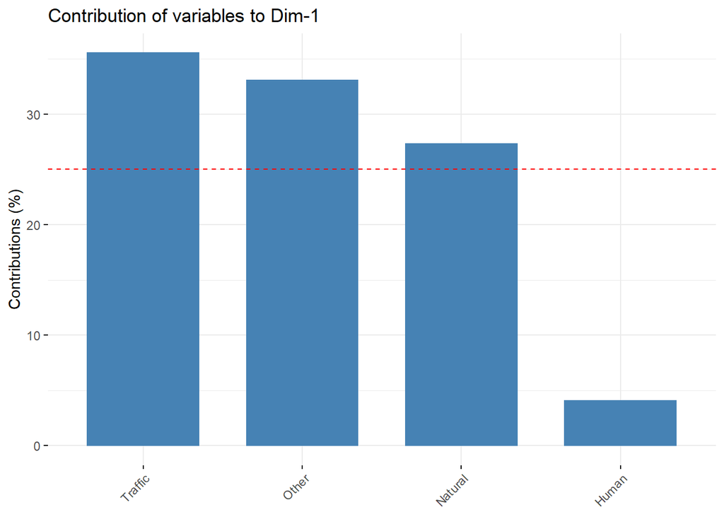

[figure not shown]

```r
fviz_contrib(res.pca, "var")
```

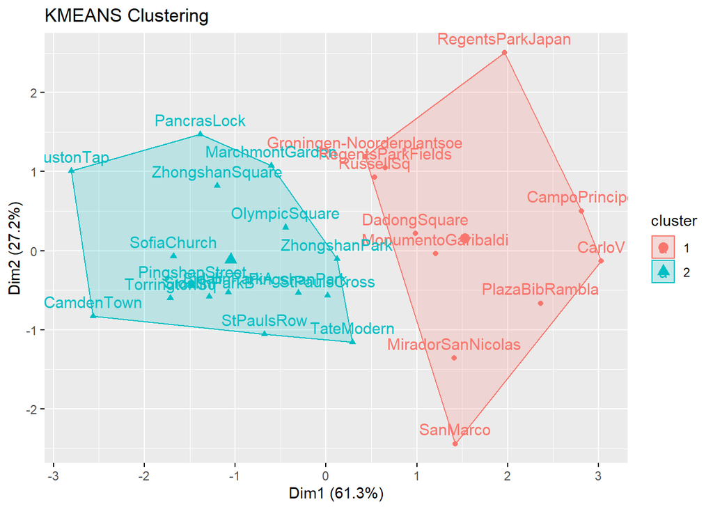

```r
fit <- eclust(means, "kmeans", k=k)
```

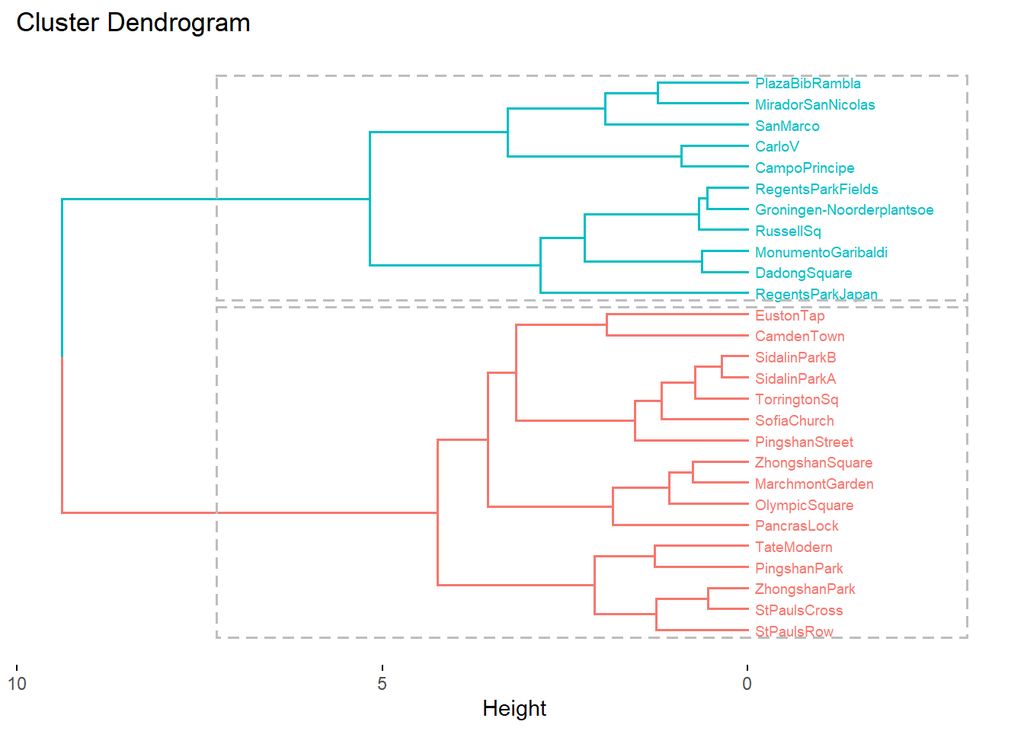

```r
h.fit <- eclust(means, "hclust", k=k, stand = T, hc_method = "ward.D2")
fviz_dend(h.fit, labels_track_height = 2.5, horiz=TRUE, rect = TRUE, cex = 0.5)
```

## Methods I haven’t really tested out thoroughly

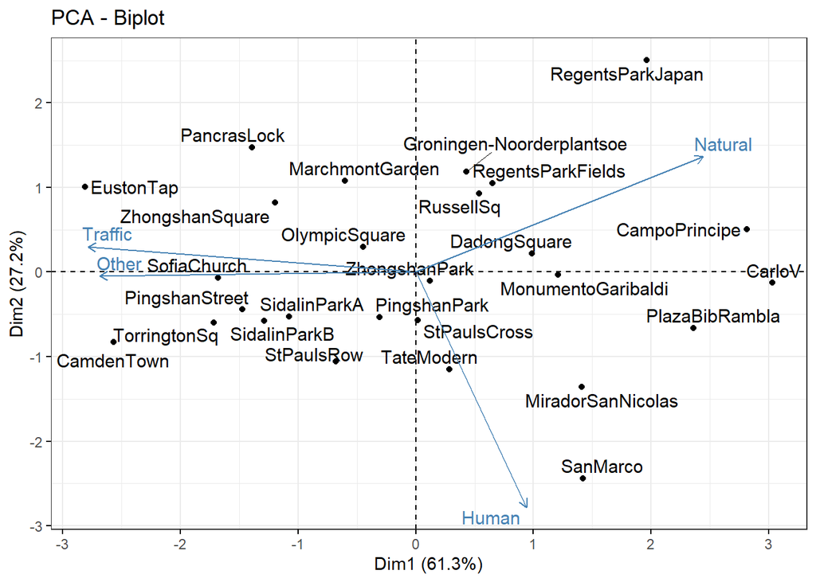

```r
fviz_pca_biplot(res.pca, repel=T,ggtheme = theme_bw())
```

### `fviz_silhouette()`

Silhouette (Si) analysis is a cluster validation approach that measures how well an observation is clustered and it estimates the average distance between clusters.

**Details**

- Observations with a large silhouette Si (almost 1) are very well clustered
- A small Si (around 0) means that the observation lies between two clusters
- Observations with a negative Si are probably placed in the wrong cluster

```
##   cluster size ave.sil.width
## 1       1   16          0.38
## 2       2   11          0.28
```

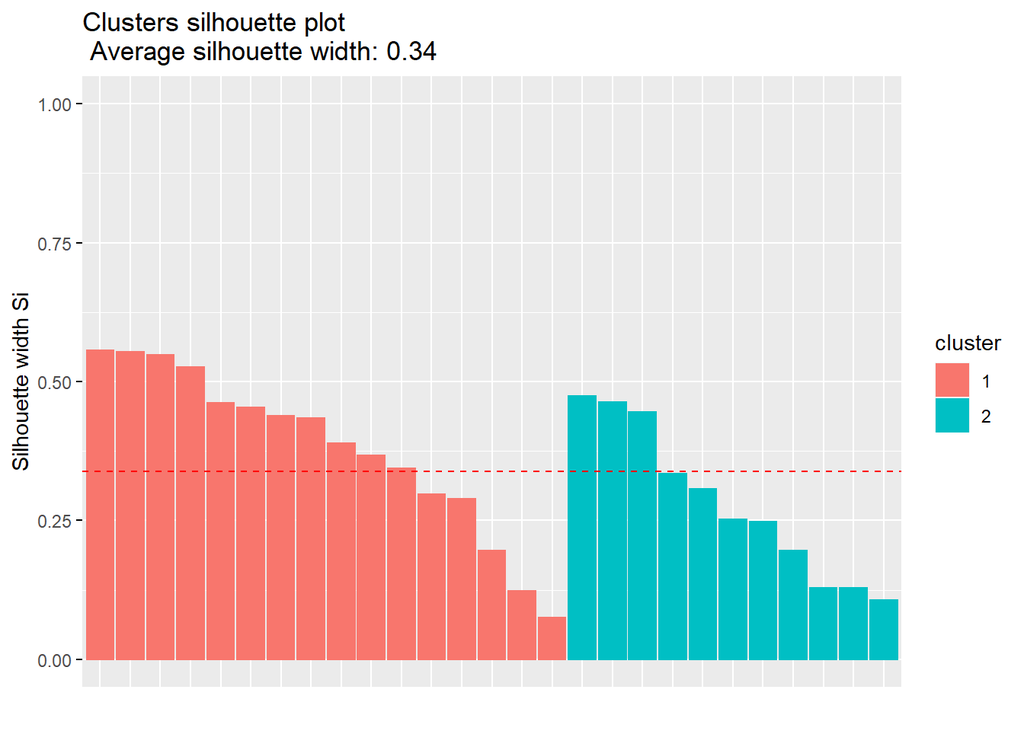

```r
fviz_silhouette(h.fit)
```

### `get_clust_tendency`

Before applying cluster methods, the first step is to assess whether the data is clusterable, a process defined as the **assessing of clustering tendency**. `get_clust_tendency()` assesses clustering tendency using Hopkins’ statistic and a visual approach.

**Details**

**Hopkins Statistic:** If the value of Hopkins statistic is close to 1 (far above 0.5), then we can conclude that the dataset is significantly clusterable.

```
## $hopkins_stat
## [1] 0.637249
##
## $plot
```

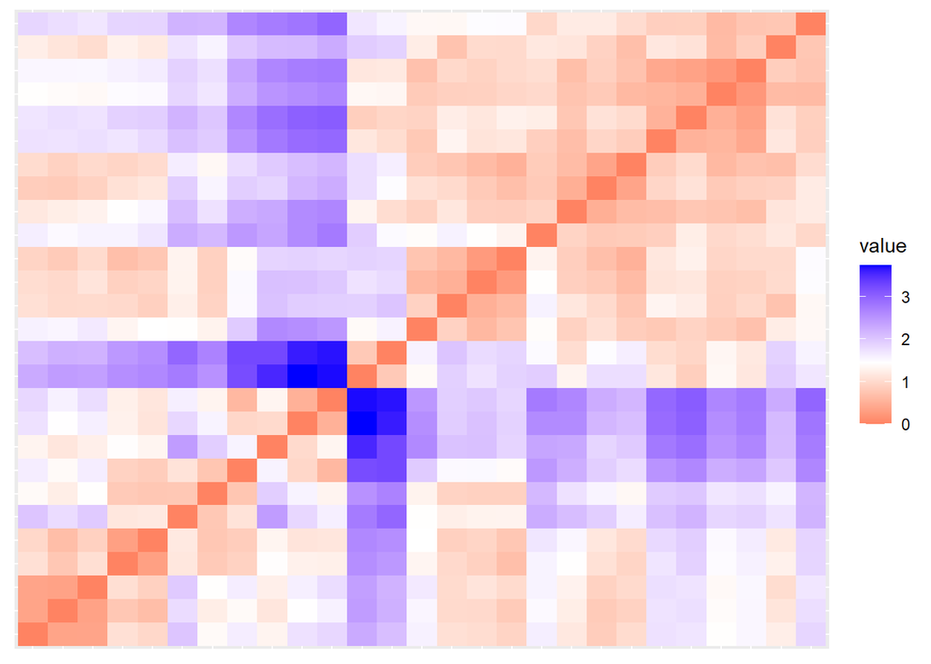